# DA 6233 Homework 1

ggplot2 Basics

Ashwin Malshe

30 September 2020

In this homework, you will use `diamonds` data set from `ggplot2` package. It is automatically loaded when you execute `library(ggplot2)` so you don’t have to separately load it. Please create a duplicate of `diamonds` and use that for homework. This will avoid corrupting the original data set.

Make sure that you understand the variables in the data by checking the help file by executing `help(diamonds)` in the console. The data has five variables that measure the dimensions. The diagram below explains these dimensions.

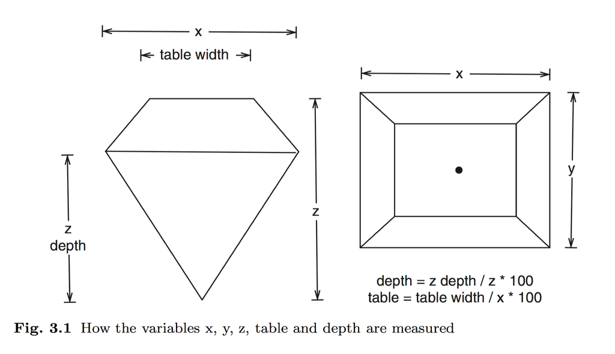

## Instructions

1. You are expected to recreate each plot **exactly** as shown in this homework.
2. The objective of this homework is to help you develop fine grain control over `ggplot2`. As such, please refrain from exercising artistic freedom!
3. All the plots use `theme_minimal()`. You can set this as your default theme by adding this line in the `setup` chunk **after** you load `ggplot2` library: `theme_set(theme_minimal())`

## Q1 (3 points)

Recreate the following graph. The parameter that controls transparency is set at 0.3. You need not get exactly the same colors but they must be **discrete** and should not follow a color gradient.

**Hint**: The points are hollow circles. Recall that we covered this specific `shape` in the last class.

**Hint**: Note that the Y axis text is modified.

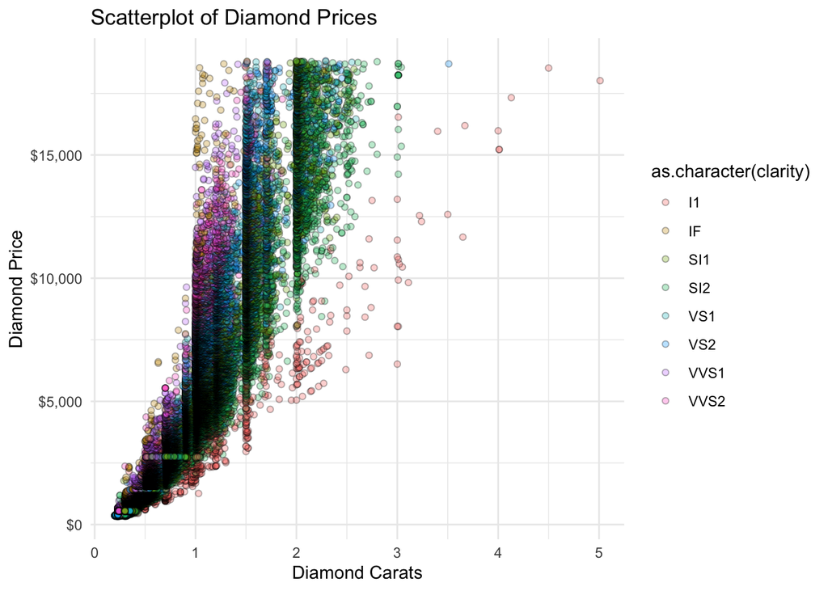

## Q2 (2 points)

The previous graph looks cluttered. So you decided to use facets instead. Recreate the following graph:

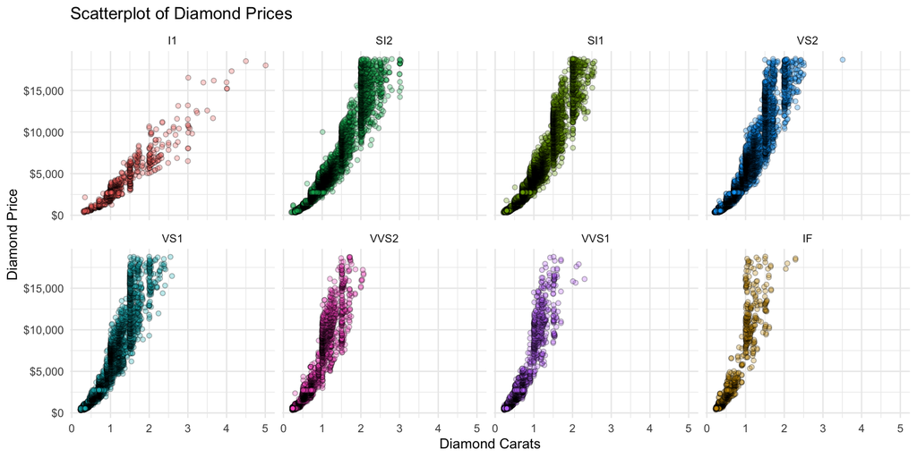

##Q3 (5 points)

Next, you want to know whether the price of diamonds depends on table and depth. Note the line types. Recreate the following graphs:

**Hint**: Pay attention to the X axis limits. Also, read up more on `linetype` [here](https://cran.r-project.org/web/packages/ggplot2/vignettes/ggplot2-specs.html). Both Q3 plots use [`geom_smooth`](https://ggplot2.tidyverse.org/reference/geom_smooth.html).

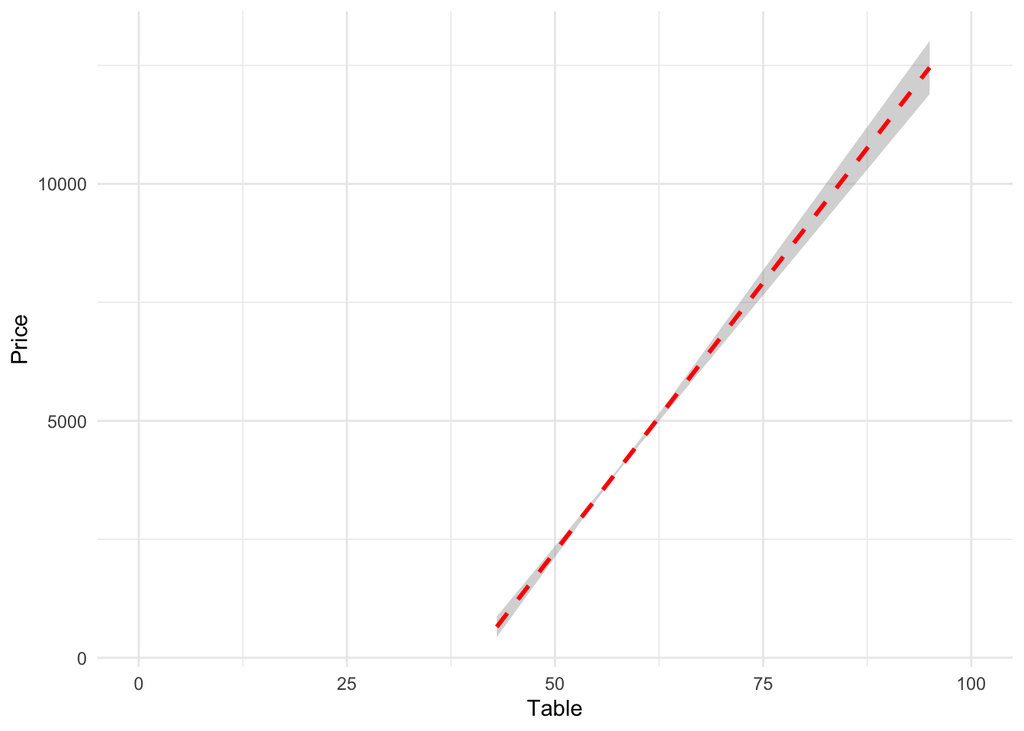

**Hint**: Pay attention to the X axis limits and breaks.

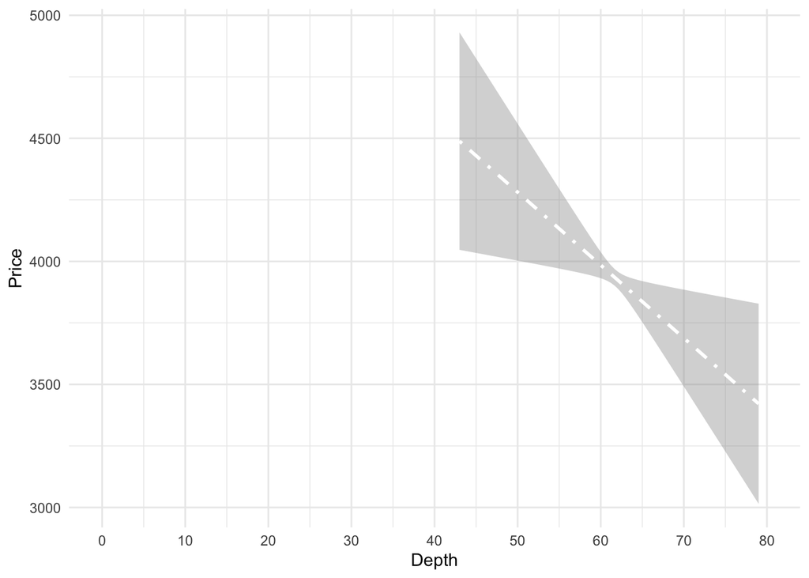

## Q4 (5 points)

Recreate each of the following graphs for data exploration:

**Hint**: In this plot, change the colors manually. Use any colors you want but I have used a color palette with these colors: 99B898, FECEAB, FF847C, E84A5F, 2A363B. If you decide to use them, don’t forget to add a `#` prefix to each color code.

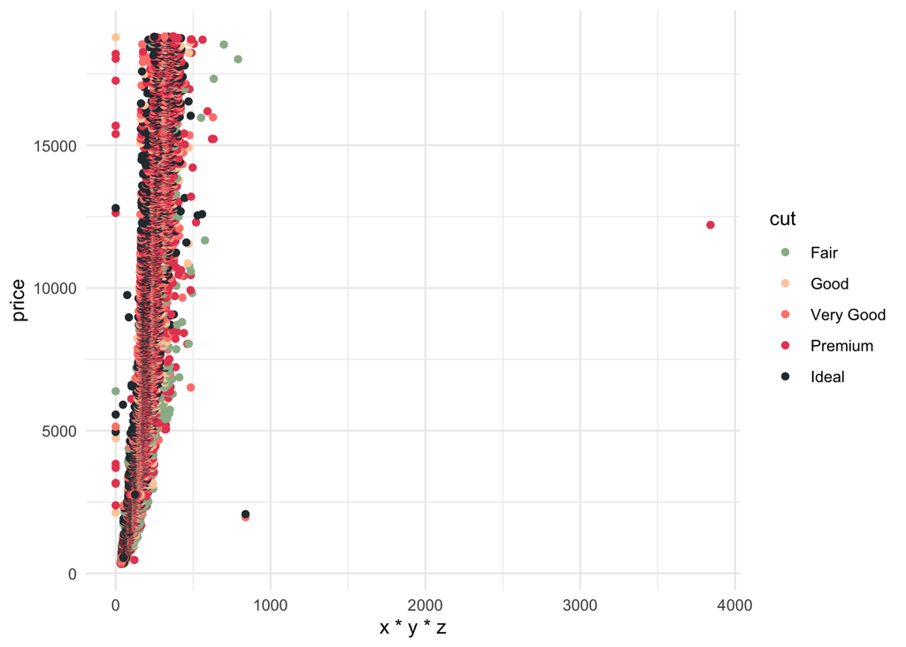

**Hint**: Pay attention to the axes text formatting

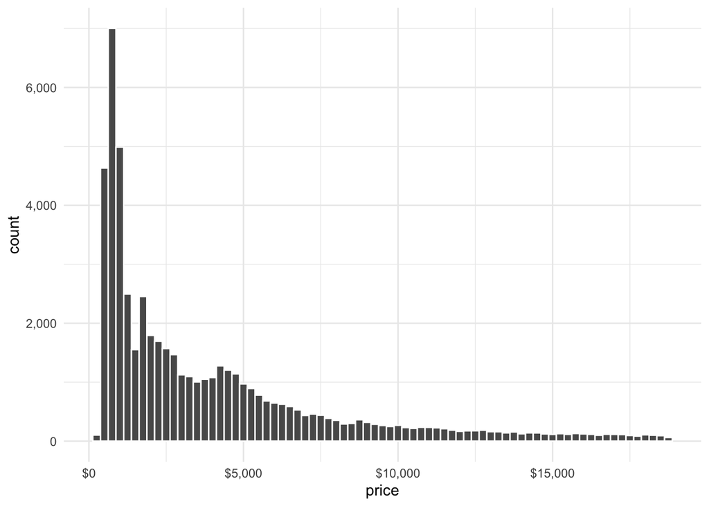

**Hint**: Note that the bars have a distinct border. You can use any color you want. Note also that the legend is not visible.

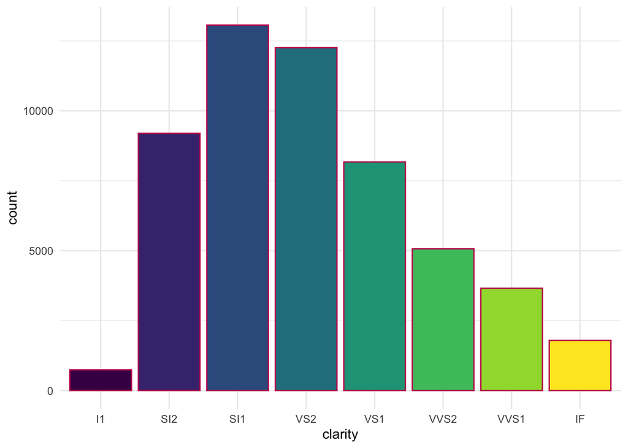

**Hint**: Here you have to use two new `geoms` for the [violin plot](https://ggplot2.tidyverse.org/reference/geom_violin.html) and the [jittered points](https://ggplot2.tidyverse.org/reference/geom_jitter.html).

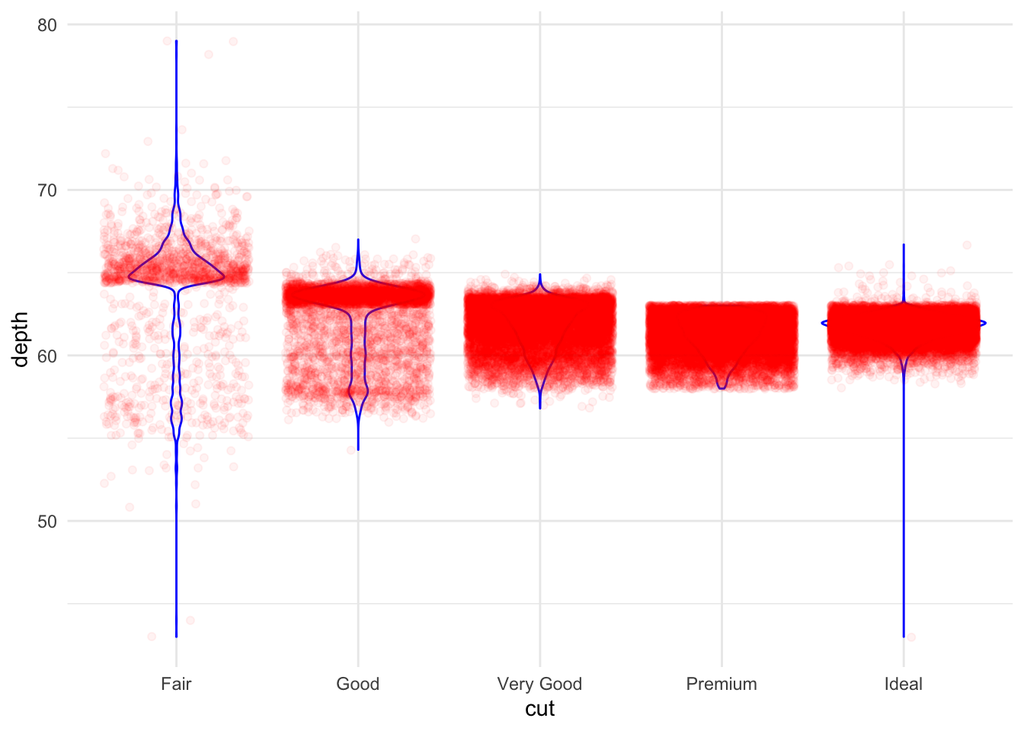

**Hint**: This plot uses two layers of [`geom_smooth`](https://ggplot2.tidyverse.org/reference/geom_smooth.html).

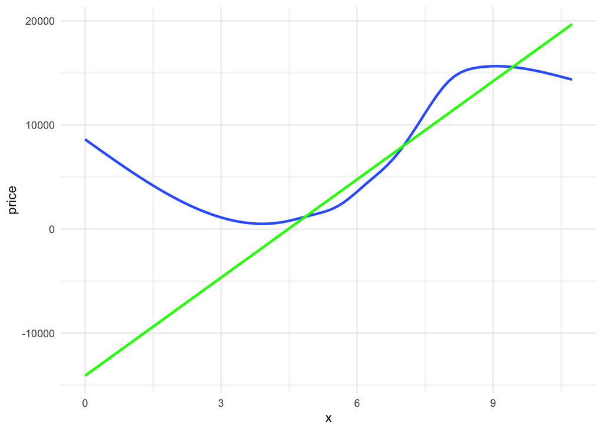